# 8116038_Question no 6-10

8116038

2082-03-16

# Q.N. 6 OR

## Using airquality dataset with R do:

## 6a. Replace missing values of “Ozone” variable with its median and save it as corrected Ozone

```r
# check working directory
# getwd()
data(airquality)
# check the structure of the dataset
str(airquality)
```

```
## 'data.frame':    153 obs. of  6 variables:
##  $ Ozone  : int  41 36 12 18 NA 28 23 19 8 NA ...
##  $ Solar.R: int  190 118 149 313 NA NA 299 99 19 194 ...
##  $ Wind   : num  7.4 8 12.6 11.5 14.3 14.9 8.6 13.8 20.1 8.6 ...
##  $ Temp   : int  67 72 74 62 56 66 65 59 61 69 ...
##  $ Month  : int  5 5 5 5 5 5 5 5 5 5 ...
##  $ Day    : int  1 2 3 4 5 6 7 8 9 10 ...
```

```r
# replace missing values of "Ozone" variable with its median
airquality$Ozone[is.na(airquality$Ozone)] <- median(airquality$Ozone, na.rm = TRUE)
# save the corrected Ozone variable
corrected_Ozone <- airquality$Ozone
# check the first few rows of the dataset
head(airquality)
```

|  | Ozone | Solar.R | Wind | Temp | Month | Day |
| --- | --- | --- | --- | --- | --- | --- |
| 1 | 41.0 | 190 | 7.4 | 67 | 5 | 1 |
| 2 | 36.0 | 118 | 8.0 | 72 | 5 | 2 |
| 3 | 12.0 | 149 | 12.6 | 74 | 5 | 3 |
| 4 | 18.0 | 313 | 11.5 | 62 | 5 | 4 |
| 5 | 31.5 | NA | 14.3 | 56 | 5 | 5 |
| 6 | 28.0 | NA | 14.9 | 66 | 5 | 6 |

```r
# check the structure of the corrected Ozone variable
str(corrected_Ozone)
```

```
##  num [1:153] 41 36 12 18 31.5 28 23 19 8 31.5 ...
```

## 6b. Get the histogram of the corrected Ozone variable usign base R plot and interpret it carefully

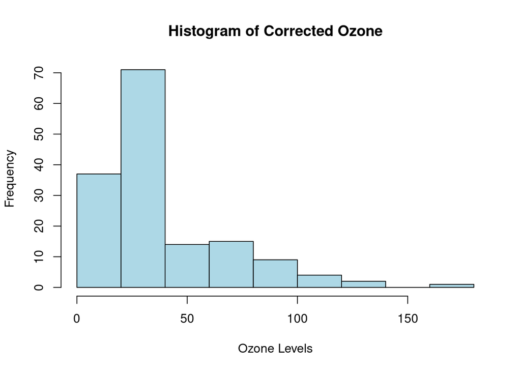

```r
# histogram of the corrected Ozone variable using base R plot
hist(corrected_Ozone,
     main = "Histogram of Corrected Ozone",
     xlab = "Ozone Levels",
     ylab = "Frequency",
     col = "lightblue",
     border = "black")
```

### The peak of the histogram is around the lower Ozone levels, with a gradual decrease in frequency as Ozone levels increase.

## 6c. Get the boxplot of the corrected Ozone variable using base R plot and interpret it carefully

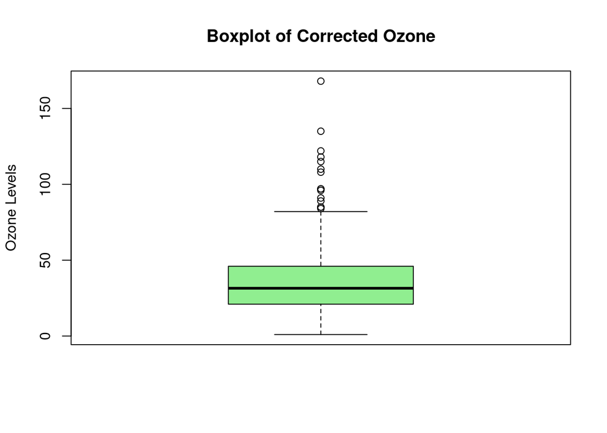

```r
# boxplot of the corrected Ozone variable using base R plot
boxplot(corrected_Ozone,
        main = "Boxplot of Corrected Ozone",
        ylab = "Ozone Levels",
        col = "lightgreen")
```

### There are many outliers present, which are represented by the points outside the whiskers of the boxplot.

## 6d. Get the summary of the corrected Ozone variable with justufication

```r
# summary of the corrected Ozone variable

summary(corrected_Ozone)
```

```
##    Min. 1st Qu.  Median    Mean 3rd Qu.    Max.
##    1.00   21.00   31.50   39.56   46.00  168.00
```

## Interpertation

### The summary of the corrected Ozone variable shows the following statistics:

### - Minimum: 1.0

### - 1st Quartile: 21.0

### - Median: 31.5

### - Mean: 39.56

### - 3rd Quartile: 46

### - Maximum: 168

### The mean Ozone level is 39.56, which is higher than the median of 31.5, indicating a right-skewed distribution.

# Q.N. 7 OR

## Do the following using mtcars data set with R

## 7a.Get the bar plot of the mpg vaiable using ggplot2 and interpret carefully

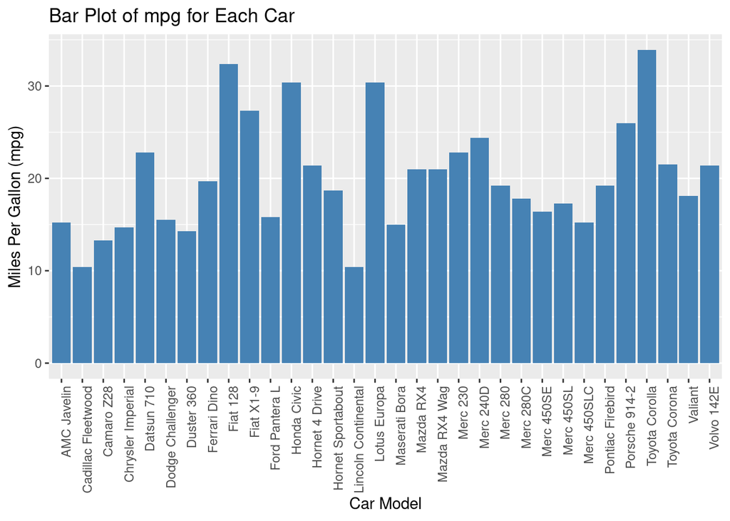

```r
library(ggplot2)
data(mtcars)

ggplot(mtcars, aes(x = factor(rownames(mtcars)), y = mpg)) +
  geom_bar(stat = "identity", fill = "steelblue") +
  labs(x = "Car Model", y = "Miles Per Gallon (mpg)", title = "Bar Plot of mpg for Each Car") +
  theme(axis.text.x = element_text(angle = 90, hjust = 1))
```

### Interpretation

This bar plot shows the miles per gallon (mpg) for each individual car model in the dataset.

Since mpg is a continuous variable, bar plots are not the most common method of representation — they are better for categorical variables.

## 7b. Get the box plot for mpg and interepret

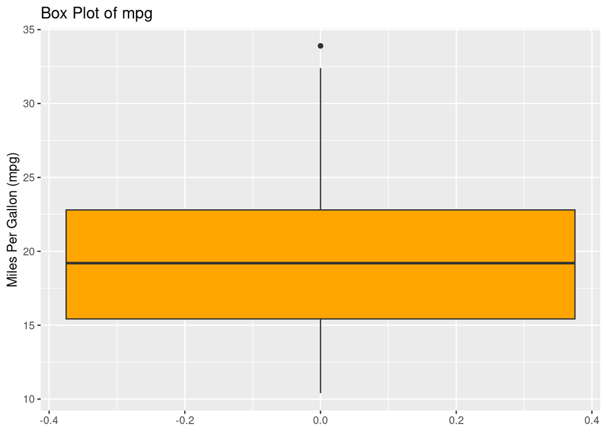

```r
ggplot(mtcars, aes(y = mpg)) +
  geom_boxplot(fill = "orange") +
  labs(y = "Miles Per Gallon (mpg)", title = "Box Plot of mpg")
```

The boxplot shows the median, interquartile range (IQR), and potential outliers for mpg.

## 7c. Get the scatter plot

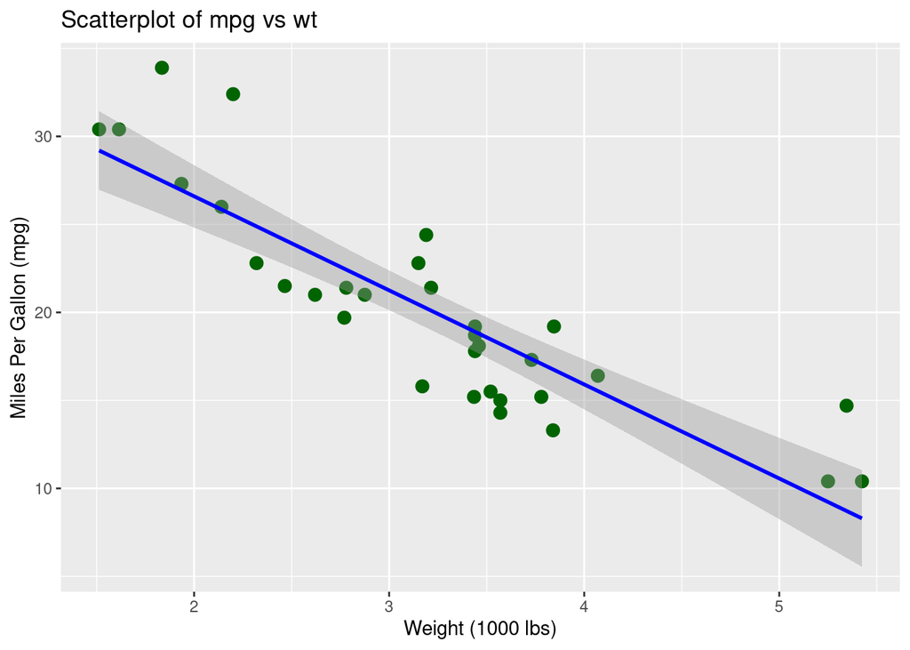

```r
ggplot(mtcars, aes(x = wt, y = mpg)) +
  geom_point(color = "darkgreen", size = 3) +
  geom_smooth(method = "lm", se = TRUE, color = "blue") +
  labs(x = "Weight (1000 lbs)", y = "Miles Per Gallon (mpg)", title = "Scatterplot of mpg vs wt")
```

This scatterplot shows the relationship between car weight (wt) and fuel efficiency (mpg).

There’s a clear negative correlation: as weight increases, mpg decreases.

Heavier cars tend to consume more fuel (lower mpg).

The line of best fit (regression line) confirms this negative trend.

## 7d. Get appropriate correlation coefficient

```r
cor(mtcars$mpg, mtcars$wt)
```

```
## [1] -0.8676594
```

Output: -0.8676

This is a strong negative correlation.

It quantifies the strength and direction of the relationship observed in the scatterplot.

It means that as the weight of a car increases, its mpg decreases significantly.

# Q.N. 8

## a. Perform shapiro-wilk test on wind variable and test normality

```r
data(airquality)
head(airquality)
```

|  | Ozone | Solar.R | Wind | Temp | Month | Day |
| --- | --- | --- | --- | --- | --- | --- |
| 1 | 41 | 190 | 7.4 | 67 | 5 | 1 |
| 2 | 36 | 118 | 8.0 | 72 | 5 | 2 |
| 3 | 12 | 149 | 12.6 | 74 | 5 | 3 |
| 4 | 18 | 313 | 11.5 | 62 | 5 | 4 |
| 5 | NA | NA | 14.3 | 56 | 5 | 5 |
| 6 | 28 | NA | 14.9 | 66 | 5 | 6 |

```r
shapiro.test(airquality$Wind)
```

```
##
##  Shapiro-Wilk normality test
##
## data:  airquality$Wind
## W = 0.98575, p-value = 0.1178
```

The Shapiro-Wilk test checks whether the Wind variable follows a normal distribution. We get p-value = 0.1178,

Since p-value > 0.05, we fail to reject H0 i.e wind is approximately normal.

## 8b. Perform bartlett test

```r
bartlett.test(Wind ~ factor(Month), data = airquality)
```

```
##
##  Bartlett test of homogeneity of variances
##
## data:  Wind by factor(Month)
## Bartlett's K-squared = 1.6178, df = 4, p-value = 0.8056
```

## Bartlett’s K-squared = 1.6178, df = 4, p-value = 0.8056

Bartlett’s test is used to test equality of variances across groups.

Since p-value > 0.05, we assume homogeneity of variance.

The p-value(0.8056) is greater than 0.05, we conclude that Wind variance is equal across months — assumption for ANOVA is satisfied.

## 8c. Fit 1-way ANOVA

```r
anova_result <- aov(Wind ~ factor(Month), data = airquality)
summary(anova_result)
```

```
##                Df Sum Sq Mean Sq F value  Pr(>F)
## factor(Month)   4  164.3   41.07   3.529 0.00879 **
## Residuals     148 1722.3   11.64
## ---
## Signif. codes:  0 '***' 0.001 '**' 0.01 '*' 0.05 '.' 0.1 ' ' 1
```

We get p-value = 0.00879.

One-way ANOVA tests whether mean wind speed is significantly different between months.

Since p-value < 0.05, we reject H0 i.e at least one month differs significantly. i.e there is a significant difference in average Wind speeds between months.

## 8d. Fit TukeyHSD with 95% CI

```r
TukeyHSD(anova_result, conf.level = 0.95)
```

```
##   Tukey multiple comparisons of means
##     95% family-wise confidence level
##
## Fit: aov(formula = Wind ~ factor(Month), data = airquality)
##
## $`factor(Month)`
##            diff       lwr        upr     p adj
## 6-5 -1.35591398 -3.768713  1.0568846 0.5305524
## 7-5 -2.68064516 -5.073585 -0.2877054 0.0197174
## 8-5 -2.82903226 -5.221972 -0.4360925 0.0117066
## 9-5 -1.44258065 -3.855379  0.9702179 0.4674045
## 7-6 -1.32473118 -3.737530  1.0880674 0.5535894
## 8-6 -1.47311828 -3.885917  0.9396803 0.4456532
## 9-6 -0.08666667 -2.519162  2.3458285 0.9999786
## 8-7 -0.14838710 -2.541327  2.2445527 0.9998052
## 9-7  1.23806452 -1.174734  3.6508631 0.6176733
## 9-8  1.38645161 -1.026347  3.7992502 0.5081147
```

Tukey’s HSD test compares all pairs of months to see which ones differ significantly.

p adj (adjusted p-value) for 7-5 and 8-5 is < 0.05, ie the that pair for months from 7-5 and 8-5 is significantly different.

On the table we see for 7-5 comparison shows p adj = 0.019 i.e Mean Wind in May is significantly different from July.

Similarly, On the table we see for 8-5 comparison shows p adj = 0.011 i.e Mean Wind in May is significantly different from August

# Q.N. 9

## 9a. Divide mtcars data into train and test data with 70:30

```r
set.seed(39)
data <- mtcars
sample_size <- floor(0.7 * nrow(data))
train_index <- sample(seq_len(nrow(data)), size = sample_size)

train_data <- data[train_index, ]
test_data <- data[-train_index, ]

print(train_data)
```

```
##                    mpg cyl  disp  hp drat    wt  qsec vs am gear carb
## Merc 230          22.8   4 140.8  95 3.92 3.150 22.90  1  0    4    2
## Honda Civic       30.4   4  75.7  52 4.93 1.615 18.52  1  1    4    2
## Merc 240D         24.4   4 146.7  62 3.69 3.190 20.00  1  0    4    2
## Ferrari Dino      19.7   6 145.0 175 3.62 2.770 15.50  0  1    5    6
## Merc 280          19.2   6 167.6 123 3.92 3.440 18.30  1  0    4    4
## Merc 450SLC       15.2   8 275.8 180 3.07 3.780 18.00  0  0    3    3
## Camaro Z28        13.3   8 350.0 245 3.73 3.840 15.41  0  0    3    4
## Merc 450SE        16.4   8 275.8 180 3.07 4.070 17.40  0  0    3    3
## Merc 450SL        17.3   8 275.8 180 3.07 3.730 17.60  0  0    3    3
## Fiat 128          32.4   4  78.7  66 4.08 2.200 19.47  1  1    4    1
## Lotus Europa      30.4   4  95.1 113 3.77 1.513 16.90  1  1    5    2
## Fiat X1-9         27.3   4  79.0  66 4.08 1.935 18.90  1  1    4    1
## Porsche 914-2     26.0   4 120.3  91 4.43 2.140 16.70  0  1    5    2
## Toyota Corolla    33.9   4  71.1  65 4.22 1.835 19.90  1  1    4    1
## Mazda RX4         21.0   6 160.0 110 3.90 2.620 16.46  0  1    4    4
## Valiant           18.1   6 225.0 105 2.76 3.460 20.22  1  0    3    1
## Hornet Sportabout 18.7   8 360.0 175 3.15 3.440 17.02  0  0    3    2
## Merc 280C         17.8   6 167.6 123 3.92 3.440 18.90  1  0    4    4
## Datsun 710        22.8   4 108.0  93 3.85 2.320 18.61  1  1    4    1
## Maserati Bora     15.0   8 301.0 335 3.54 3.570 14.60  0  1    5    8
## Ford Pantera L    15.8   8 351.0 264 4.22 3.170 14.50  0  1    5    4
## Toyota Corona     21.5   4 120.1  97 3.70 2.465 20.01  1  0    3    1
```

```r
print(test_data)
```

```
##                      mpg cyl disp  hp drat    wt  qsec vs am gear carb
## Mazda RX4 Wag       21.0   6  160 110 3.90 2.875 17.02  0  1    4    4
## Hornet 4 Drive      21.4   6  258 110 3.08 3.215 19.44  1  0    3    1
## Duster 360          14.3   8  360 245 3.21 3.570 15.84  0  0    3    4
## Cadillac Fleetwood  10.4   8  472 205 2.93 5.250 17.98  0  0    3    4
## Lincoln Continental 10.4   8  460 215 3.00 5.424 17.82  0  0    3    4
## Chrysler Imperial   14.7   8  440 230 3.23 5.345 17.42  0  0    3    4
## Dodge Challenger    15.5   8  318 150 2.76 3.520 16.87  0  0    3    2
## AMC Javelin         15.2   8  304 150 3.15 3.435 17.30  0  0    3    2
## Pontiac Firebird    19.2   8  400 175 3.08 3.845 17.05  0  0    3    2
## Volvo 142E          21.4   4  121 109 4.11 2.780 18.60  1  1    4    2
```

## 9b. Fit linear regression and KNN

```r
# Linear regression
lm_model <- lm(mpg ~ ., data = train_data)

# KNN
library(caret)
library(dplyr)
# Preprocessing: scale and center
pre_proc <- preProcess(train_data, method = c("center", "scale"))
train_scaled <- predict(pre_proc, train_data)
test_scaled <- predict(pre_proc, test_data)

# KNN Regression
set.seed(39)
knn_model <- train(mpg ~ ., data = train_scaled, method = "knn", tuneLength = 5)
```

## 9c. Predict value for wt = 6000lbs

```r
# Predict with linear regression
lm_pred <- predict(lm_model, newdata = test_data)

# Predict with KNN
knn_pred <- predict(knn_model, newdata = test_scaled)

# Create a new data point
new_data <- data.frame(t(colMeans(data)))
new_data$wt <- 6  # set weight to 6000 lbs

# For linear regression
lm_wt6_pred <- predict(lm_model, newdata = new_data)

# For KNN: preprocess new data
new_data_scaled <- predict(pre_proc, new_data)
knn_wt6_pred <- predict(knn_model, newdata = new_data_scaled)

# Print predictions
lm_wt6_pred
```

```
##       1
## 5.00931
```

```r
knn_wt6_pred
```

```
## [1] -0.7654543
```

Using linear model the predicted value is 5.009 which seems to be correct, on the other hand with knn it is -0.76 which do not seem to be correct.

## 9d. Compare the fit indices

```r
# Actual values
actual <- test_data$mpg

# Metrics function
get_metrics <- function(actual, predicted) {
  mse <- mean((actual - predicted)^2)
  rmse <- sqrt(mse)
  rss <- sum((actual - predicted)^2)
  tss <- sum((actual - mean(actual))^2)
  rsq <- 1 - rss/tss
  return(c(R2 = rsq, MSE = mse, RMSE = rmse))
}

# Linear Regression metrics
lm_metrics <- get_metrics(actual, lm_pred)

# KNN metrics
knn_metrics <- get_metrics(actual, knn_pred)

# Combine results
metrics_df <- data.frame(
  Model = c("Linear Regression", "KNN"),
  R_Squared = c(lm_metrics["R2"], knn_metrics["R2"]),
  MSE = c(lm_metrics["MSE"], knn_metrics["MSE"]),
  RMSE = c(lm_metrics["RMSE"], knn_metrics["RMSE"])
)

print(metrics_df)
```

```
##               Model    R_Squared       MSE      RMSE
## 1 Linear Regression  -0.04267725  16.73758  4.091158
## 2               KNN -17.67534289 299.78594 17.314328
```

Best model is Linear regression because;

### R-squared:

Linear Regression: -0.043

KNN: -17.675 ; much worse

Though both are negative (which is bad), KNN performs very poorly in explaining the variance in mpg.

### MSE & RMSE:

Linear Regression: MSE = 16.74, RMSE = 4.09

KNN: MSE = 299.79, RMSE = 17.31

## Lower values in linear regression indicate much better predictive accuracy.

## NOTE

A negative R square means the model is performing worse than just predicting the mean.

This implies that both models are not fitting well, possibly due to:

- Small test sample size
- Multicollinearity or irrelevant predictors
- No tuning of KNN (e.g., wrong k)
- Outliers or non-linear relationships

# Q.N. 10

## 10a. Fit HCA using single linkage

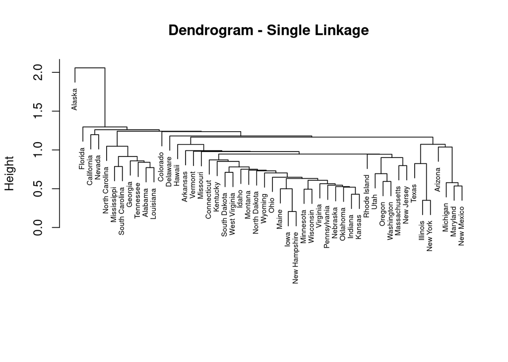

```r
data("USArrests")

# Remove missing values and scale data
usarrests_scaled <- scale(USArrests)

# Compute distance matrix
dist_matrix <- dist(usarrests_scaled)

# Fit hierarchical clustering using single linkage
hc_single <- hclust(dist_matrix, method = "single")

# Plot dendrogram
plot(hc_single, main = "Dendrogram - Single Linkage", xlab = "", sub = "", cex = 0.6)
```

## 10b. Fit HCA using complete linkage

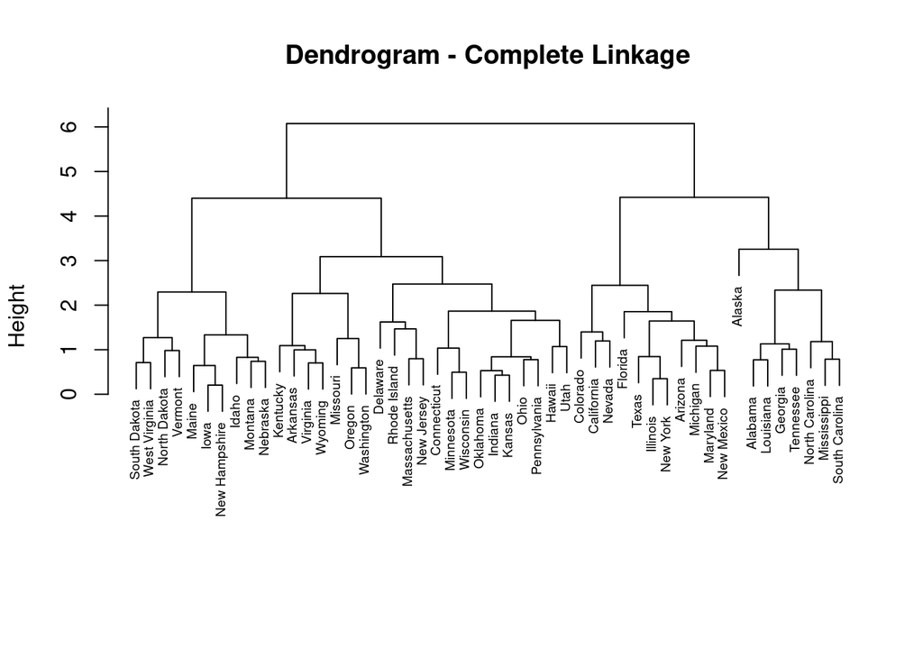

```r
hc_complete <- hclust(dist_matrix, method = "complete")

plot(hc_complete, main = "Dendrogram - Complete Linkage", xlab = "", sub = "", cex = 0.6)
```

## 10c. Fit HCA using average linkage

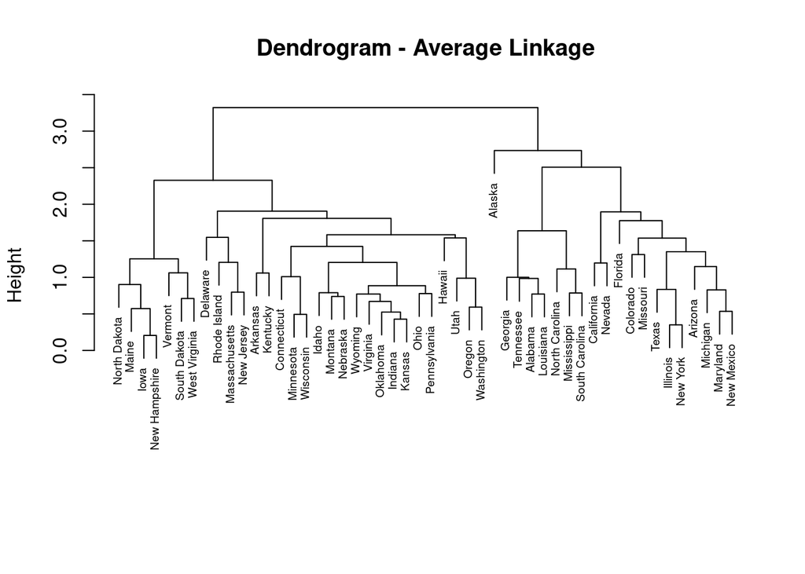

```r
hc_average <- hclust(dist_matrix, method = "average")

plot(hc_average, main = "Dendrogram - Average Linkage", xlab = "", sub = "", cex = 0.6)
```

## 10d. show number of cluster

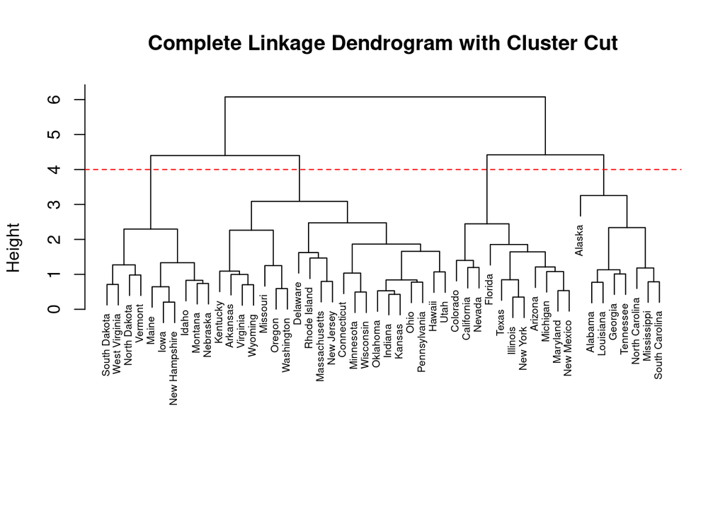

```r
# Plot best model's dendrogram (complete linkage)
plot(hc_complete, main = "Complete Linkage Dendrogram with Cluster Cut", xlab = "", sub = "", cex = 0.6)

# Add abline to cut the dendrogram (adjust height to choose k)
abline(h = 4, col = "red", lty = 2)
```

```r
# Cut tree into clusters,i.e 4 clusters
clusters <- cutree(hc_complete, k = 4)

# Add cluster labels
print(clusters)
```

```
##        Alabama         Alaska        Arizona       Arkansas     California
##              1              1              2              3              2
##       Colorado    Connecticut       Delaware        Florida        Georgia
##              2              3              3              2              1
##         Hawaii          Idaho       Illinois        Indiana           Iowa
##              3              4              2              3              4
##         Kansas       Kentucky      Louisiana          Maine       Maryland
##              3              3              1              4              2
##  Massachusetts       Michigan      Minnesota    Mississippi       Missouri
##              3              2              3              1              3
##        Montana       Nebraska         Nevada  New Hampshire     New Jersey
##              4              4              2              4              3
##     New Mexico       New York North Carolina   North Dakota           Ohio
##              2              2              1              4              3
##       Oklahoma         Oregon   Pennsylvania   Rhode Island South Carolina
##              3              3              3              3              1
##   South Dakota      Tennessee          Texas           Utah        Vermont
##              4              1              2              3              4
##       Virginia     Washington  West Virginia      Wisconsin        Wyoming
##              3              3              4              3              3
```

Hence from the graph we can see that cutting at height 4 of the complete linkage forms 4 clusters. So the best model can be with complete linkage.